# Machine Learning 2019: Feature Selection

Peter Stella

October 24, 2019

## Feature Selection

In machine learning, feature selection is the process of choosing variables that are useful in predicting the response variable. Selecting the right features in your data can mean the difference between mediocre performance with long training times and great performance with short training times that are less computationally intensive.

Often, data can contain attributes that are highly correlated with each other or not useful in helping predict our response variable. Many methods perform better if such variables are removed. Feature selection is usually imporant to implement during the data pre-processing steps of machine learning.

## The Breast Cancer Dataset

699 Observations, 11 variables Predictor Variable: Class- benign or malignant

```r
data(BreastCancer)
head(BreastCancer)
```

|  | Id | Cl.thickness | Cell.size | Cell.shape | Marg.adhesion | Epith.c.size | Bare.nuclei | Bl.cromatin | Normal.nucleoli | Mitoses | Class |
| --- | --- | --- | --- | --- | --- | --- | --- | --- | --- | --- | --- |
| 1 | 1000025 | 5 | 1 | 1 | 1 | 2 | 1 | 3 | 1 | 1 | benign |
| 2 | 1002945 | 5 | 4 | 4 | 5 | 7 | 10 | 3 | 2 | 1 | benign |
| 3 | 1015425 | 3 | 1 | 1 | 1 | 2 | 2 | 3 | 1 | 1 | benign |
| 4 | 1016277 | 6 | 8 | 8 | 1 | 3 | 4 | 3 | 7 | 1 | benign |
| 5 | 1017023 | 4 | 1 | 1 | 3 | 2 | 1 | 3 | 1 | 1 | benign |
| 6 | 1017122 | 8 | 10 | 10 | 8 | 7 | 10 | 9 | 7 | 1 | malignant |

```r
dim(BreastCancer)
```

```
## [1] 699  11
```

```r
summary(BreastCancer$Class)
```

```
##    benign malignant
##       458       241
```

## Homework

1. Compare the most important features from at least 2 different classes of feature selection methods covered in this tutorial with any reasonable machine learning dataset from mlbench. Do these feature selection methods provide similar results?

1.1 Correlation matrix on bosting housing data

```r
data("BostonHousing2")
#coerce to numeric, place dependent variables, town names to left hand side for easy manipulation.
BH2num <- BostonHousing2 %>% mutate(tract = as.numeric(tract), chas = as.numeric(chas), rad=as.numeric(rad), tax=as.numeric(tax))
BH2num <- BH2num %>% dplyr::select(cmedv, medv, town, everything())
```

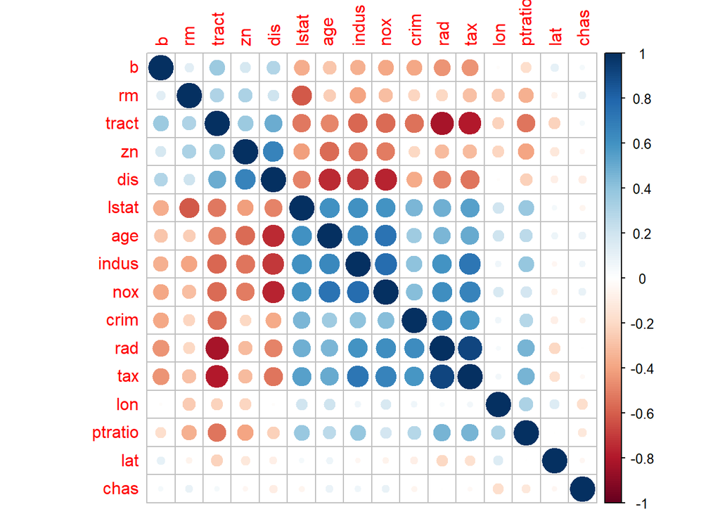

```r
#calculate correlation matrix using pearson correlation
correlation_matrix = cor(BH2num[,4:19])
corrplot(correlation_matrix, order = "hclust")
```

```r
highly_correlatedp <- colnames(BH2num[])[findCorrelation(correlation_matrix, cutoff = 0.7, verbose = TRUE)]
```

```
## Compare row 13  and column  1 with corr  0.794
##   Means:  0.468 vs 0.327 so flagging column 13
## Compare row 1  and column  12 with corr  0.829
##   Means:  0.435 vs 0.31 so flagging column 1
## Compare row 6  and column  8 with corr  0.764
##   Means:  0.427 vs 0.288 so flagging column 6
## Compare row 8  and column  10 with corr  0.731
##   Means:  0.403 vs 0.268 so flagging column 8
## Compare row 10  and column  11 with corr  0.748
##   Means:  0.352 vs 0.247 so flagging column 10
## All correlations <= 0.7
```

```r
highly_correlatedp
```

```
## [1] "age"   "cmedv" "lat"   "zn"    "chas"
```

1.2 Lasso:

Covert to matrix.

```r
BHmat <- as.matrix(BH2num[,4:19])
BHmatval <- as.matrix(BH2num[,1])
```

```r
#fit Lasso model
bhlasso <- cv.glmnet(BHmat, BHmatval, family='gaussian', alpha=1, type.measure='mse',parallel=TRUE, standardize=TRUE)
```

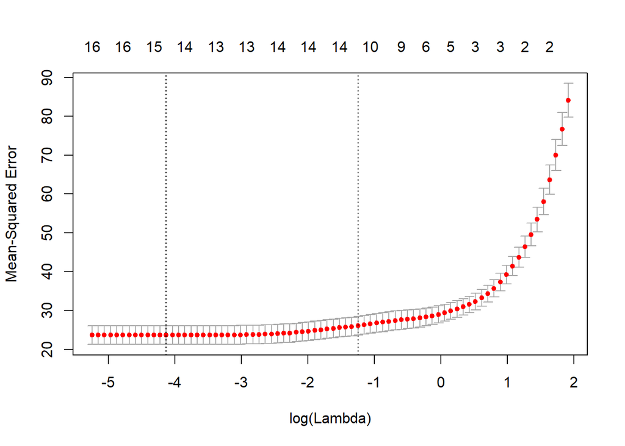

```r
plot(bhlasso)
```

```r
cat('Min Lambda: ', bhlasso$lambda.min, '\n 1Sd Lambda: ', bhlasso$lambda.1se)
```

```
## Min Lambda:  0.01606851
##  1Sd Lambda:  0.2874092
```

```r
df_coef <- round(as.matrix(coef(bhlasso, s=bhlasso$lambda.min)), 2)
df_coef
```

```
##                   1
## (Intercept) -320.90
## tract          0.00
## lon           -5.29
## lat           -0.50
## crim          -0.10
## zn             0.04
## indus          0.00
## chas           2.53
## nox          -15.05
## rm             3.83
## age            0.00
## dis           -1.35
## rad            0.20
## tax           -0.01
## ptratio       -0.90
## b              0.01
## lstat         -0.53
```

1.3

Random forest

```r
str(BH2num)
```

```
## 'data.frame':    506 obs. of  19 variables:
##  $ cmedv  : num  24 21.6 34.7 33.4 36.2 28.7 22.9 22.1 16.5 18.9 ...
##  $ medv   : num  24 21.6 34.7 33.4 36.2 28.7 22.9 27.1 16.5 18.9 ...
##  $ town   : Factor w/ 92 levels "Arlington","Ashland",..: 54 77 77 46 46 46 69 69 69 69 ...
##  $ tract  : num  2011 2021 2022 2031 2032 ...
##  $ lon    : num  -71 -71 -70.9 -70.9 -70.9 ...
##  $ lat    : num  42.3 42.3 42.3 42.3 42.3 ...
##  $ crim   : num  0.00632 0.02731 0.02729 0.03237 0.06905 ...
##  $ zn     : num  18 0 0 0 0 0 12.5 12.5 12.5 12.5 ...
##  $ indus  : num  2.31 7.07 7.07 2.18 2.18 2.18 7.87 7.87 7.87 7.87 ...
##  $ chas   : num  1 1 1 1 1 1 1 1 1 1 ...
##  $ nox    : num  0.538 0.469 0.469 0.458 0.458 0.458 0.524 0.524 0.524 0.524 ...
##  $ rm     : num  6.58 6.42 7.18 7 7.15 ...
##  $ age    : num  65.2 78.9 61.1 45.8 54.2 58.7 66.6 96.1 100 85.9 ...
##  $ dis    : num  4.09 4.97 4.97 6.06 6.06 ...
##  $ rad    : num  1 2 2 3 3 3 5 5 5 5 ...
##  $ tax    : num  296 242 242 222 222 222 311 311 311 311 ...
##  $ ptratio: num  15.3 17.8 17.8 18.7 18.7 18.7 15.2 15.2 15.2 15.2 ...
##  $ b      : num  397 397 393 395 397 ...
##  $ lstat  : num  4.98 9.14 4.03 2.94 5.33 ...
```

```r
train_size <- floor(0.75 * nrow(BH2num))
train_pos <- sample(seq_len(nrow(BH2num)), size = train_size)

rftrain <- BH2num[train_pos, ]
rftest <- BH2num[-train_pos, ]

#fit a model
rfmodel = randomForest(cmedv ~ tract + lon +lat + crim +  zn + indus + chas + nox +rm + age + dis + rad +tax + ptratio + b + lstat, data=rftrain,  importance = TRUE, oob.times = 15, confusion = TRUE)

importance(rfmodel)
```

```
##           %IncMSE IncNodePurity
## tract   14.675287    2283.19862
## lon     14.697202    2094.18891
## lat      9.925491     419.61769
## crim    12.972239    1464.83666
## zn       2.436720      85.40614
## indus    9.736015    1268.11885
## chas     3.777168     206.04741
## nox     13.826284    1353.05258
## rm      33.608959    9601.18421
## age     12.678074     782.59159
## dis     15.064450    1810.97374
## rad      4.710518     143.01149
## tax     11.789057     835.95932
## ptratio 14.111264    1904.86122
## b        5.028095     381.09564
## lstat   26.849355    9930.11555
```

```r
rfmodel
```

```
##
## Call:
##  randomForest(formula = cmedv ~ tract + lon + lat + crim + zn +      indus + chas + nox + rm + age + dis + rad + tax + ptratio +      b + lstat, data = rftrain, importance = TRUE, oob.times = 15,      confusion = TRUE)
##                Type of random forest: regression
##                      Number of trees: 500
## No. of variables tried at each split: 5
##
##           Mean of squared residuals: 9.87578
##                     % Var explained: 89.34
```

```r
rfpredict <- predict(rfmodel, rftest)
summary(rfpredict)
```

```
##    Min. 1st Qu.  Median    Mean 3rd Qu.    Max.
##   8.747  16.558  20.339  21.030  23.803  46.921
```

```r
rferror <- (rfpredict-rftest$cmedv)
rferrorsum <- data.frame(rftest$cmedv, rfpredict, rferror)
mserror <- mean(rferror^2)
mserror
```

```
## [1] 7.952958
```

2. Attempt a feature selection method not covered in this tutorial (backward elimination, forward propogation, etc.)

2.1 Forward selection

Remove medv and town information

```r
BH2num2 <- BH2num %>% dplyr::select(-medv,-town)
str(BH2num2)
```

```
## 'data.frame':    506 obs. of  17 variables:
##  $ cmedv  : num  24 21.6 34.7 33.4 36.2 28.7 22.9 22.1 16.5 18.9 ...
##  $ tract  : num  2011 2021 2022 2031 2032 ...
##  $ lon    : num  -71 -71 -70.9 -70.9 -70.9 ...
##  $ lat    : num  42.3 42.3 42.3 42.3 42.3 ...
##  $ crim   : num  0.00632 0.02731 0.02729 0.03237 0.06905 ...
##  $ zn     : num  18 0 0 0 0 0 12.5 12.5 12.5 12.5 ...
##  $ indus  : num  2.31 7.07 7.07 2.18 2.18 2.18 7.87 7.87 7.87 7.87 ...
##  $ chas   : num  1 1 1 1 1 1 1 1 1 1 ...
##  $ nox    : num  0.538 0.469 0.469 0.458 0.458 0.458 0.524 0.524 0.524 0.524 ...
##  $ rm     : num  6.58 6.42 7.18 7 7.15 ...
##  $ age    : num  65.2 78.9 61.1 45.8 54.2 58.7 66.6 96.1 100 85.9 ...
##  $ dis    : num  4.09 4.97 4.97 6.06 6.06 ...
##  $ rad    : num  1 2 2 3 3 3 5 5 5 5 ...
##  $ tax    : num  296 242 242 222 222 222 311 311 311 311 ...
##  $ ptratio: num  15.3 17.8 17.8 18.7 18.7 18.7 15.2 15.2 15.2 15.2 ...
##  $ b      : num  397 397 393 395 397 ...
##  $ lstat  : num  4.98 9.14 4.03 2.94 5.33 ...
```

```r
modelf1 <- lm(cmedv ~ ., data=BH2num2)
modelf2 <- lm(cmedv ~ 1, data=BH2num2)
step <- stepAIC(modelf2, direction="forward", scope = list(upper=modelf1, lower= modelf2))
```

```
## Start:  AIC=2244.87
## cmedv ~ 1
##
##           Df Sum of Sq   RSS    AIC
## + lstat    1   23368.3 19209 1844.1
## + rm       1   20643.3 21934 1911.2
## + ptratio  1   10886.6 31691 2097.4
## + indus    1   10005.2 32573 2111.3
## + tax      1    9484.8 33093 2119.3
## + nox      1    7847.0 34731 2143.8
## + tract    1    7808.7 34769 2144.3
## + crim     1    6462.2 36116 2163.6
## + rad      1    6303.4 36274 2165.8
## + age      1    6083.6 36494 2168.8
## + zn       1    5529.9 37048 2176.5
## + b        1    4774.3 37803 2186.7
## + lon      1    4440.6 38137 2191.1
## + dis      1    2646.5 39931 2214.4
## + chas     1    1313.8 41264 2231.0
## <none>                 42578 2244.9
## + lat      1       2.0 42576 2246.8
##
## Step:  AIC=1844.13
## cmedv ~ lstat
##
##           Df Sum of Sq   RSS    AIC
## + rm       1    3986.8 15223 1728.4
## + ptratio  1    2585.8 16624 1773.0
## + lon      1    1403.0 17807 1807.8
## + dis      1     799.1 18410 1824.6
## + chas     1     786.4 18423 1825.0
## + age      1     311.1 18898 1837.9
## + tax      1     287.7 18922 1838.5
## + b        1     199.2 19010 1840.9
## + zn       1     152.1 19057 1842.1
## + crim     1     145.5 19064 1842.3
## + tract    1      99.3 19110 1843.5
## + indus    1      93.9 19116 1843.7
## <none>                 19210 1844.1
## + lat      1      70.5 19139 1844.3
```

[output cut: 165 more lines]

```
## + lon    1    50.826 10774 1575.5
## <none>               10825 1575.9
## + indus  1     4.930 10820 1577.7
## + lat    1     0.841 10824 1577.9
## + age    1     0.138 10825 1577.9
##
## Step:  AIC=1575.55
## cmedv ~ lstat + rm + ptratio + dis + nox + chas + b + zn + tract +
##     crim + tax + rad + lon
##
##         Df Sum of Sq   RSS    AIC
## <none>               10774 1575.5
## + lat    1   1.95850 10772 1577.5
## + indus  1   1.35638 10773 1577.5
## + age    1   0.83662 10774 1577.5
```

```r
step$anova
```

| Step | Df | Deviance | Resid. Df | Resid. Dev | AIC |
| --- | --- | --- | --- | --- | --- |
|  | NA | NA | 505 | 42577.74 | 2244.870 |
| + lstat | 1 | 23368.27962 | 504 | 19209.46 | 1844.130 |
| + rm | 1 | 3986.78483 | 503 | 15222.67 | 1728.426 |
| + ptratio | 1 | 1648.13132 | 502 | 13574.54 | 1672.444 |
| + dis | 1 | 520.34174 | 501 | 13054.20 | 1654.666 |
| + nox | 1 | 781.94175 | 500 | 12272.26 | 1625.411 |
| + chas | 1 | 330.54989 | 499 | 11941.71 | 1613.595 |
| + b | 1 | 273.26511 | 498 | 11668.44 | 1603.882 |
| + zn | 1 | 196.67534 | 497 | 11471.77 | 1597.281 |
| + tract | 1 | 108.51058 | 496 | 11363.26 | 1594.472 |

[output cut: 4 more lines]